# Generation of bsseq object with escapee CpGs (filtered with meth in hPGC > 30%) present in Hsu et al.

Gaja Matassa

Date: May 23, 2025

# 1. Environment setting

```r
library(ggplot2)
library(bsseq)
library(scales)
library(gridExtra)
library(dplyr)
library(dmrseq)
library(annotatr)
library(sechm)
library(rtracklayer)
source("../Methylation_helper.R")
OutputFolder <- params$OutputFolder
if (dir.exists(OutputFolder) == FALSE) {
  dir.create(OutputFolder, recursive=TRUE)
}
```

# 2. Loading data

## 2.1 BSSeq object

Loading of bsseq object with CpGs from Hsu et al.

```r
bsseq_obj <- readRDS("/group/testa/Project/PGCLC/NewData_fromLaSitua/7.EscapeesExploration/bsseq_Hsu_complete.rds")
```

## 2.3 Escapees regions

These escapees regions were filtered from the regions found in [Tang et al. 2015](https://doi.org/10.1016/j.cell.2015.04.053). In particular, those covered by at least 10 CpGs in all (Tang et al. 2015) human primordial germ cell (hPGC) samples and with methylation levels above 30% in (Tang et al. 2015) week 5-9 hPGC samples were selected.

```r
EscapeesRegions <- readxl::read_xlsx("~/DataDir/7.EscapeesExploration/Output/EscapeesFiltering/FirstFilteringRegions.xlsx")
```

```r
EscapeesRegions_GRanges_hg19 <- makeGRangesFromDataFrame(EscapeesRegions, seqnames.field = "Chr", start.field = "Start", end.field = "End", keep.extra.columns = FALSE, na.rm=TRUE)
```

We have 9856 escapees regions with a total of 735308 CpGs.

**These regions are hg19 and need to be converted to hg38 to be compared with our data**

```r
path = "~/DataDir/7.EscapeesExploration/hg19ToHg38.over.chain"
ch = import.chain(path)
str(ch[[1]])
## Formal class 'ChainBlock' [package "rtracklayer"] with 6 slots
##   ..@ ranges  :Formal class 'IRanges' [package "IRanges"] with 6 slots
##   .. .. ..@ start          : int [1:1239] 16847851 16867628 16867672 16867743 16867854 16876217 16876254 16876567 16876586 16876682 ...
##   .. .. ..@ width          : int [1:1239] 19737 43 47 96 8362 36 312 18 95 33 ...
##   .. .. ..@ NAMES          : NULL
##   .. .. ..@ elementType    : chr "ANY"
##   .. .. ..@ elementMetadata: NULL
##   .. .. ..@ metadata       : list()
##   ..@ offset  : int [1:1239] 480662 480702 480702 480726 480726 480726 480726 480726 480726 480726 ...
##   ..@ score   : int [1:16] -1063871317 61356972 1903041 1027915 538227 6814 4748 4372 4314 3439 ...
##   ..@ space   : chr [1:16] "chr22" "chr22" "chr22" "chr22" ...
##   ..@ reversed: logi [1:16] FALSE TRUE FALSE FALSE TRUE FALSE ...
##   ..@ length  : int [1:16] 1129 18 2 26 50 2 1 1 2 1 ...

if ("UCSC" %in% seqlevelsStyle(EscapeesRegions_GRanges_hg19)) {
  EscapeesRegions_GRanges_hg38 = liftOver(EscapeesRegions_GRanges_hg19, ch)
  EscapeesRegions_GRanges_hg38 = unlist(EscapeesRegions_GRanges_hg38)
}else{stop("The seqlevels style should be UCSC!!!")}
```

```r
length(EscapeesRegions_GRanges_hg38)
```

```
## [1] 10191
```

After the conversion we have 10191 escapees regions.

```r
EscapeesRegions_GRanges <- EscapeesRegions_GRanges_hg38
```

# 3. Generation of BSSeq oject with escapee CpGs and non-escapee CpGs

```r
bsseq_ranges_df <- granges(bsseq_obj) %>% as.data.frame() #granges has 0-based position they seem 1-based. Look here for explanation: https://www.biostars.org/p/84686/
bsseq_ranges_df$end <- bsseq_ranges_df$start + 1 #to make them 0-based
bsseq_granges <- makeGRangesFromDataFrame(bsseq_ranges_df, starts.in.df.are.0based = TRUE)

bsseq_obj_1based <- bsseq_obj
bsseq_obj_1based@rowRanges <- bsseq_granges
granges(bsseq_obj_1based)
## GRanges object with 27815552 ranges and 0 metadata columns:
##                   seqnames    ranges strand
##                      <Rle> <IRanges>  <Rle>
##          [1]          chr1     10469      *
##          [2]          chr1     10471      *
##          [3]          chr1     10484      *
##          [4]          chr1     10489      *
##          [5]          chr1     10493      *
##          ...           ...       ...    ...
##   [27815548] chrKI270757.1     70889      *
##   [27815549] chrKI270757.1     70921      *
##   [27815550] chrKI270757.1     70922      *
##   [27815551] chrKI270757.1     70982      *
##   [27815552] chrKI270757.1     70983      *
##   -------
##   seqinfo: 175 sequences from an unspecified genome; no seqlengths
```

This to obtain a bsseq object with only CpGs contained in the escapees regions

```r
m <- findOverlaps(bsseq_granges, EscapeesRegions_GRanges)

bsseq_obj_escapees <- bsseq_obj_1based[queryHits(m),]
```

With our targeted kit we are able to cover **302502** CpGs belonging to all the escapees regions (41.14%).

Let’s create also a bsseq object with non-escapee CpGs (all the other CpGs that are not in escapees regions)

```r
bsseq_obj_NonEscapees <- bsseq_obj_1based[-queryHits(m),]
```

# 4. Violin plots

## 4.1 showing global trend (and mean) of 5mCs + 5hmCs in escapee regions

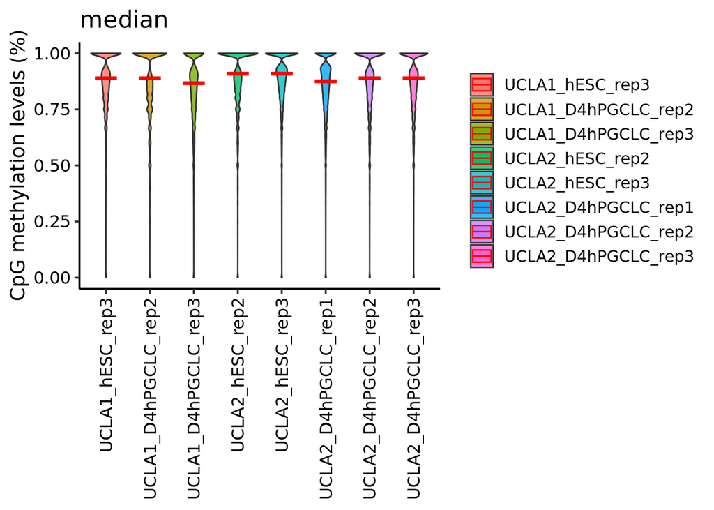

```r
violin_plot(assays(bsseq_obj_escapees)$Meth_WGBS, stat="median")
## No id variables; using all as measure variables
```

## 4.2 showing global trend (and mean) of only 5hmCs in escapee regions

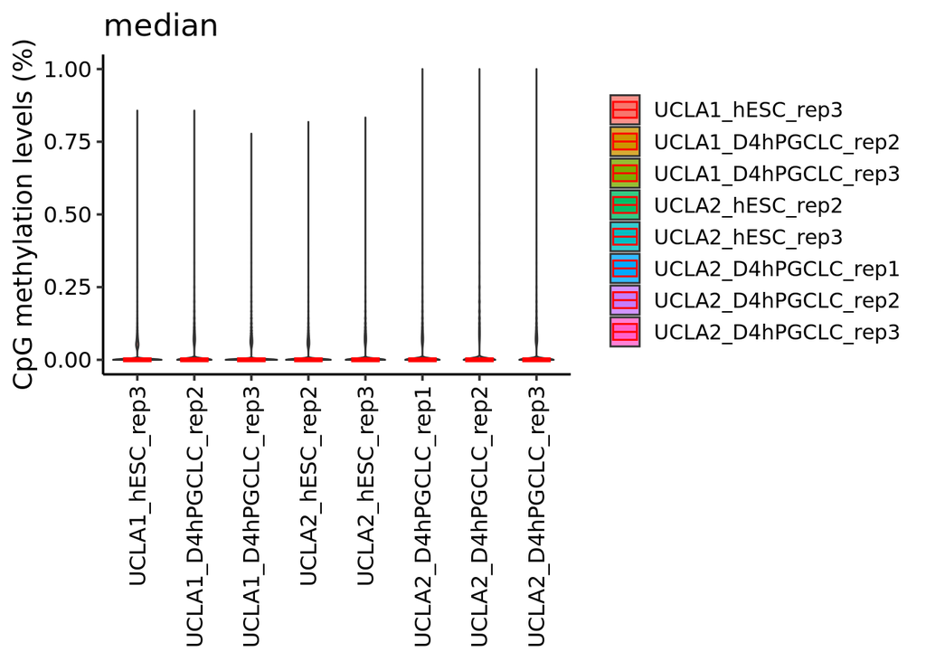

```r
violin_plot(assays(bsseq_obj_escapees)$Meth_hmC, stat="median")
## No id variables; using all as measure variables
```

## 4.3 showing global trend (and mean) of only 5mCs in escapee regions

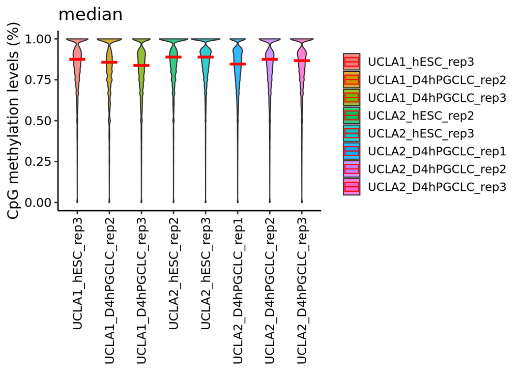

```r
violin_plot(assays(bsseq_obj_escapees)$Meth_mC, stat="median")
## No id variables; using all as measure variables
```

# 5. Saving and Session Info

Saving:

- DataFrame of Escapee regions after filtering and conversion to hg38 (excel format)
- bsseq object subset with only CpGs in escapees regions where hPGCs have meth > 0.3
- bsseq object subset with non-escapee CpGs (all the other CpGs that are not in escapees regions)

```r
#openxlsx::write.xlsx(as.data.frame(EscapeesRegions_GRanges) %>% rename(chr = seqnames), file = paste0(OutputFolder, "EscapeeRegions_hg38.xlsx"))
saveRDS(bsseq_obj_escapees, paste0(OutputFolder, "bsseq_obj_escapees_Hsu.rds"))
saveRDS(bsseq_obj_NonEscapees, paste0(OutputFolder, "bsseq_obj_NonEscapees_Hsu.rds"))
```

```r
date()
```

```
## [1] "Fri May 23 12:39:35 2025"
```